# Project Timeseries

2022-11-20

```r
if(!require(tidyverse)){
    install.packages(tidyverse)
}
```

```
## ───────────────────────────────────────
## tidyverse 1.3.2 ──
```

```r
library(tidyverse)
library(forecast)
library(forecast)
library("TTR")
library(tseries)
library(fpp)
```

Lecture des datas:

```r
day <- read.csv("day.csv")
hour <- read.csv("hour.csv")
```

```r
head(day)
```

```
##   instant     dteday season yr mnth holiday weekday workingday weathersit
## 1       1 2011-01-01      1  0    1       0       6          0          2
## 2       2 2011-01-02      1  0    1       0       0          0          2
## 3       3 2011-01-03      1  0    1       0       1          1          1
## 4       4 2011-01-04      1  0    1       0       2          1          1
## 5       5 2011-01-05      1  0    1       0       3          1          1
## 6       6 2011-01-06      1  0    1       0       4          1          1
##       temp    atemp      hum windspeed casual registered  cnt
## 1 0.344167 0.363625 0.805833 0.1604460    331        654  985
## 2 0.363478 0.353739 0.696087 0.2485390    131        670  801
## 3 0.196364 0.189405 0.437273 0.2483090    120       1229 1349
## 4 0.200000 0.212122 0.590435 0.1602960    108       1454 1562
## 5 0.226957 0.229270 0.436957 0.1869000     82       1518 1600
## 6 0.204348 0.233209 0.518261 0.0895652     88       1518 1606
```

## 1)a)

### Distribution de temperatures en fonction des saisons:

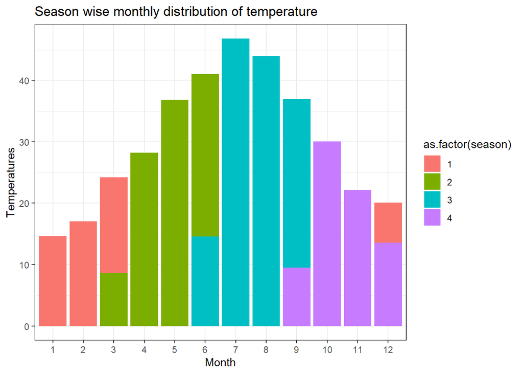

```r
ggplot(day,aes(x=as.factor(mnth),y=temp,fill=as.factor(season)))+theme_bw()+geom_col()+
labs(x='Month',y='Temperatures',title='Season wise monthly distribution of temperature')
```

```r
#TODO: Change labels (especially as factor of seasons)
```

On voit que les temperatures augmentent jusqu’a la moitie de l’annee puis redescendent ensuite. Par ailleurs, on remarque que les temperatures sont les plus eleves pendant la saison 3(c’est a dire l’été), et baissent pendant la saison 4 (automne) jusqu’a devenir minimales en saison 1 (hivers).

On peut aussi visualiser avec des boxplots:

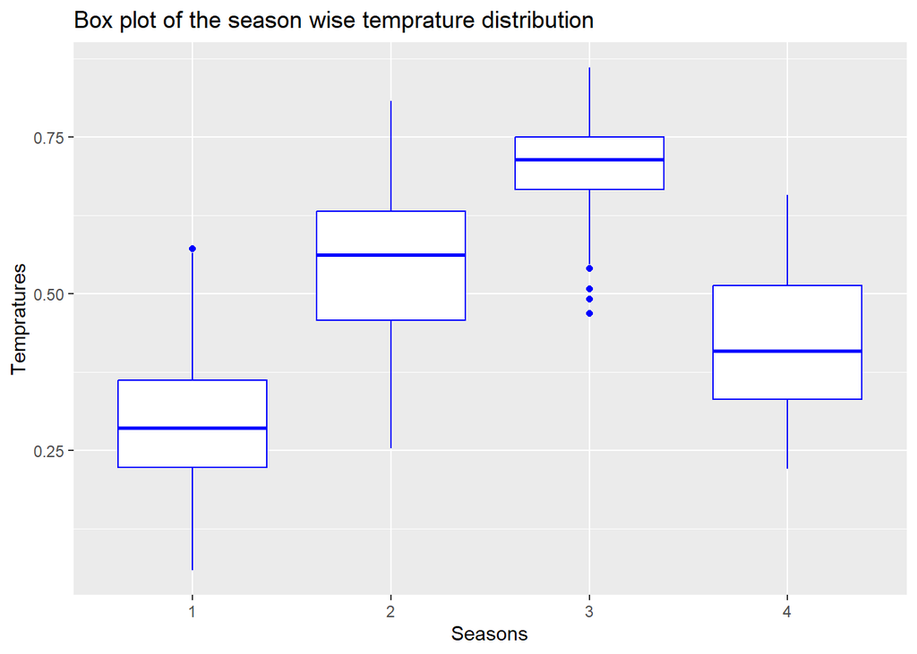

```r
ggplot(day, aes(x=as.factor(season),y=temp)) +
  geom_boxplot(color = "blue") +
  labs(x='Seasons',y='Tempratures',title='Box plot of the season wise temprature distribution')
```

On remarque d’il y a des outliers en saison 1(hiver) et 3(ete),avec des valeurs qui sont respectivement plus elevees que la normale et plus basses.

### Moyenne des temperatures:

```r
mean(day$temp)
```

```
## [1] 0.4953848
```

### Mediane des temperatures:

```r
median(day$temp)
```

```
## [1] 0.498333
```

On a une temperature moyenne de 0.49538 et une mediane de 0.49833.

## 1)b)

### Correlation entre la temperature temp et le nombre total de location de vélos cnt:

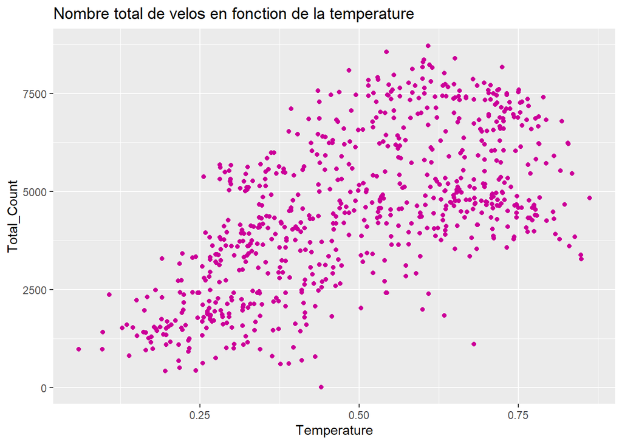

```r
ggplot(data = day) +
  geom_point(mapping = aes(x = temp, y = cnt), color = "#CC0099") +
  labs(x='Temperature',y='Total_Count',title='Nombre total de velos en fonction de la temperature')
```

Les points forment une figure etiree. On peut envisager une correlation lineaire entre les deux variables. Pour verifier cela, on calcule la correlation:

```r
cor.test(day$temp, day$cnt, method=c("pearson", "kendall", "spearman"))
```

```
##
##  Pearson's product-moment correlation
##
## data:  day$temp and day$cnt
## t = 21.759, df = 729, p-value < 2.2e-16
## alternative hypothesis: true correlation is not equal to 0
## 95 percent confidence interval:
##  0.5814369 0.6695422
## sample estimates:
##      cor
## 0.627494
```

Le coefficient de correlation est de 0.627, ce qui n’est pas extrêmement élevé, de plus, la p-value est inférieure a 5%, ce qui veut dire que la correlation est statistiquement significative.

On fait de meme pour les variables atemp et cnt:

### Correlation entre la temperature ressentie atemp et le nombre total de location de vélos cnt:

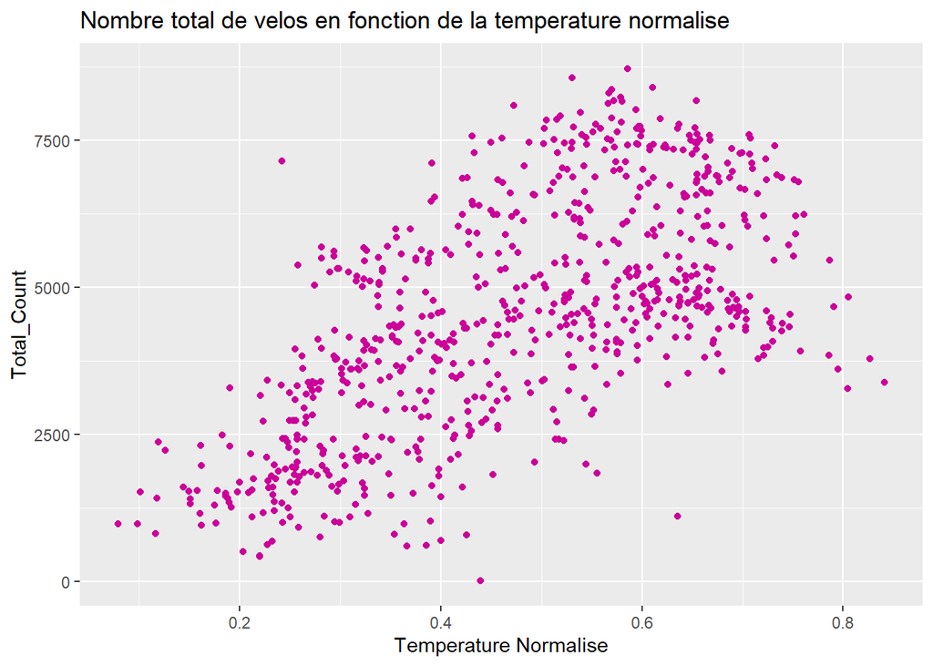

```r
ggplot(data = day) +
  geom_point(mapping = aes(x = atemp, y = cnt), color = "#CC0099") +
  labs(x='Temperature Normalise',y='Total_Count',title='Nombre total de velos en fonction de la temperature normalise')
```

```r
cor.test(day$atemp, day$cnt, method=c("pearson", "kendall", "spearman"))
```

```
##
##  Pearson's product-moment correlation
##
## data:  day$atemp and day$cnt
## t = 21.965, df = 729, p-value < 2.2e-16
## alternative hypothesis: true correlation is not equal to 0
## 95 percent confidence interval:
##  0.5853376 0.6727918
## sample estimates:
##       cor
## 0.6310657
```

On constate la meme chose pour la variable atemp, il n’y a pas une grande differance entre la relation cnt-temp et cnt-atemp.

### Correlation entre la moyenne des temperatures réelles et ressenties (temp et atemp) et le nombre total de location de vélos cnt:

Pour la correlation entre cnt et mean(temp, atemp), on rajoute une colonne qui represente la moyenne entre temp et atemp, puis on repete les memes operations:

```r
day$"mean_temp_atemp" <- apply(day[, 10:11], 1, mean)
head(day)
```

```
##   instant     dteday season yr mnth holiday weekday workingday weathersit
## 1       1 2011-01-01      1  0    1       0       6          0          2
## 2       2 2011-01-02      1  0    1       0       0          0          2
## 3       3 2011-01-03      1  0    1       0       1          1          1
## 4       4 2011-01-04      1  0    1       0       2          1          1
## 5       5 2011-01-05      1  0    1       0       3          1          1
## 6       6 2011-01-06      1  0    1       0       4          1          1
##       temp    atemp      hum windspeed casual registered  cnt mean_temp_atemp
## 1 0.344167 0.363625 0.805833 0.1604460    331        654  985       0.3538960
## 2 0.363478 0.353739 0.696087 0.2485390    131        670  801       0.3586085
## 3 0.196364 0.189405 0.437273 0.2483090    120       1229 1349       0.1928845
## 4 0.200000 0.212122 0.590435 0.1602960    108       1454 1562       0.2060610
## 5 0.226957 0.229270 0.436957 0.1869000     82       1518 1600       0.2281135
## 6 0.204348 0.233209 0.518261 0.0895652     88       1518 1606       0.2187785
```

On affiche les données:

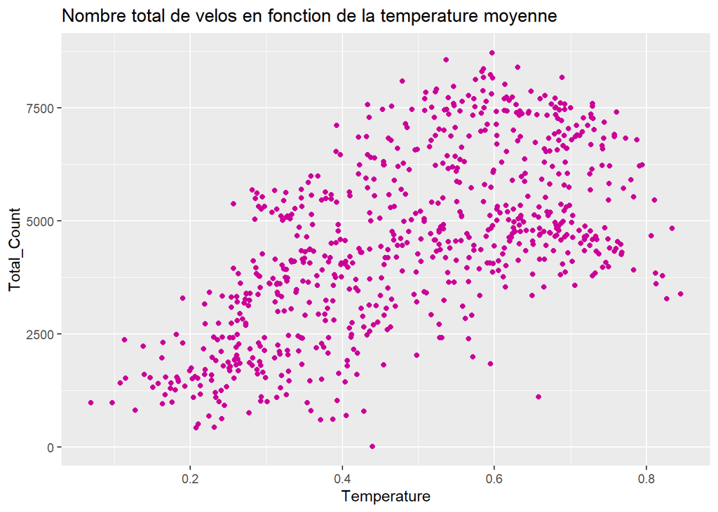

```r
ggplot(data = day) +
  geom_point(mapping = aes(x = mean_temp_atemp, y = cnt), color = "#CC0099") +
  labs(x='Temperature',y='Total_Count',title='Nombre total de velos en fonction de la temperature moyenne')
```

```r
cor.test(day$mean_temp_atemp, day$cnt, method=c("pearson", "kendall", "spearman"))
```

```
##
##  Pearson's product-moment correlation
##
## data:  day$mean_temp_atemp and day$cnt
## t = 21.931, df = 729, p-value < 2.2e-16
## alternative hypothesis: true correlation is not equal to 0
## 95 percent confidence interval:
##  0.584699 0.672260
## sample estimates:
##       cor
## 0.6304811
```

On obtient un resulat similaire avec un coefficient de correlation est de 0.6305, et une p-value inférieure a 5%, ce qui veut dire que la correlation est statistiquement significative.

## 1)c)

### Temperatures moyennes par mois:

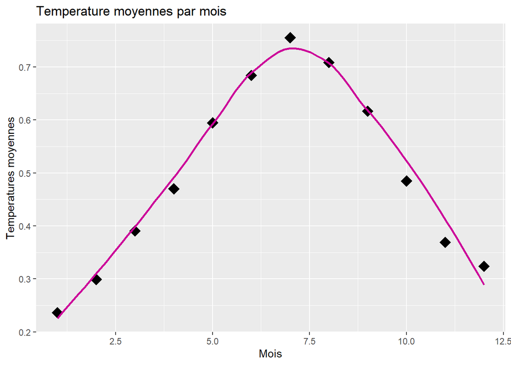

```r
#Temperatures moyennes
Temperatures_moyennes <- aggregate(day$temp, list(day$mnth), FUN=mean, na.rm=TRUE)
ggplot(data = Temperatures_moyennes, mapping = aes(x = Group.1, y = x)) +
  geom_point(  shape = 18, size = 5) +
  geom_smooth(formula = y ~ x, method = "loess",se = FALSE,  color = "#CC0099")  +
  labs(x= "Mois", y =  "Temperatures moyennes", title="Temperature moyennes par mois" ) +
  xlim(1,12)
```

### Humidite moyennes par mois:

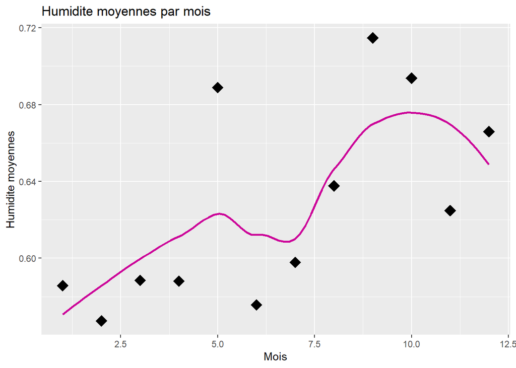

```r
#Humidite moyenne
Hum_moyennes <- aggregate(day$hum, list(day$mnth), FUN=mean, na.rm=TRUE)
ggplot(data = Hum_moyennes, mapping = aes(x = Group.1, y = x)) +
  geom_point(  shape = 18, size = 5) +
  geom_smooth(formula = y ~ x, method = "loess",se = FALSE,  color = "#CC0099")  +
  labs(x= "Mois", y =  "Humidite moyennes", title="Humidite moyennes par mois" ) +
  xlim(1,12)
```

### Vent moyen par mois:

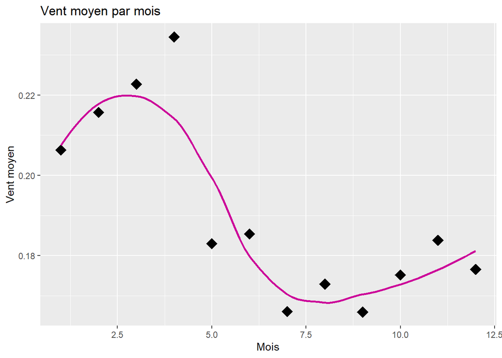

```r
#Vent moyen
Vent_moyen <- aggregate(day$windspeed, list(day$mnth), FUN=mean, na.rm=TRUE)
ggplot(data = Vent_moyen, mapping = aes(x = Group.1, y = x)) +
  geom_point(  shape = 18, size = 5) +
  geom_smooth(formula = y ~ x, method = "loess",se = FALSE,  color = "#CC0099")  +
  labs(x= "Mois", y =  "Vent moyen", title="Vent moyen par mois" ) +
  xlim(1,12)
```

### Moyenne du total de velos loues par mois:

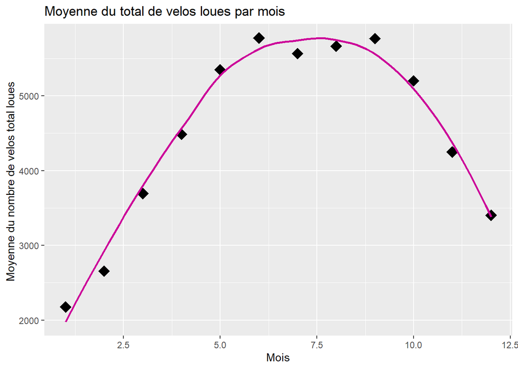

```r
#Total velos loues moyennes
Total_moyen <- aggregate(day$cnt, list(day$mnth), FUN=mean, na.rm=TRUE)
ggplot(data = Total_moyen, mapping = aes(x = Group.1, y = x)) +
  geom_point(  shape = 18, size = 5) +
  geom_smooth(formula = y ~ x, method = "loess",se = FALSE,  color = "#CC0099")  +
  labs(x= "Mois", y =  "Moyenne du nombre de velos total loues ", title="Moyenne du total de velos loues par mois" ) +
  xlim(1,12)
```

## 1)d)

### correlation temp et les locations de vélos:

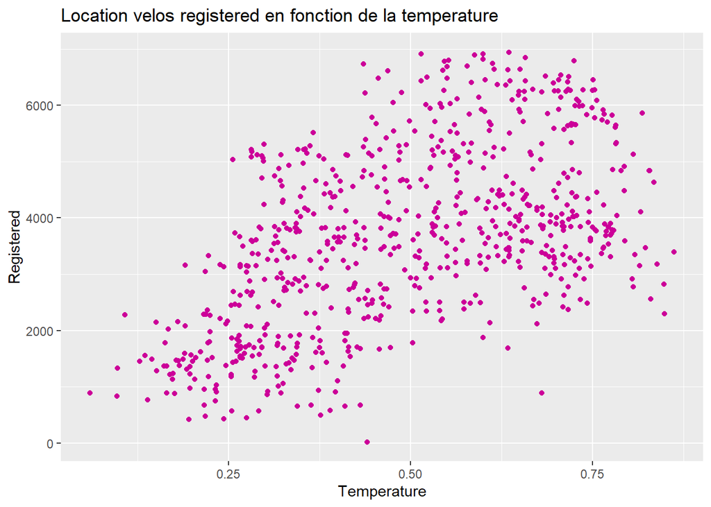

```r
ggplot(data = day) +
  geom_point(mapping = aes(x =temp, y = registered), color = "#CC0099") +
  labs(x='Temperature',y='Registered',title='Location velos registered en fonction de la temperature')
```

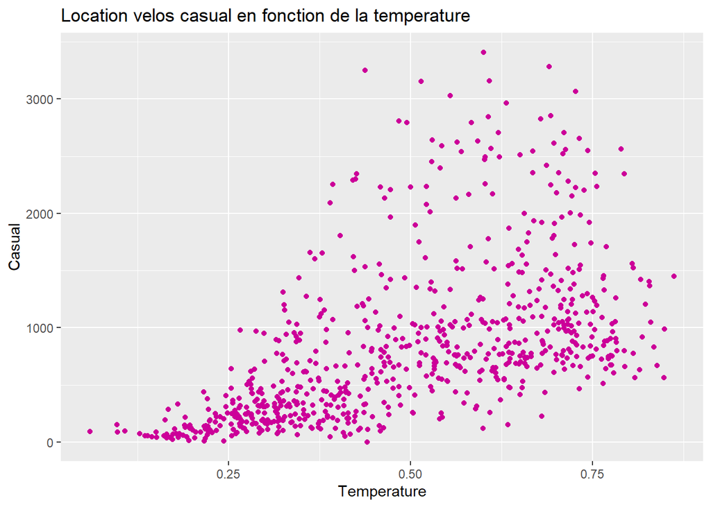

```r
ggplot(data = day) +
  geom_point(mapping = aes(x =temp, y = casual), color = "#CC0099") +
  labs(x='Temperature',y='Casual',title='Location velos casual en fonction de la temperature')
```

Il semble y avoir une relation entre temp et registered/casual, en effet on remarque que les deux variables augmentent dans le meme sense.

On peut calculer le coefficient de corelation:

```r
cor.test(day$temp, day$registered, method=c("pearson", "kendall", "spearman"))
```

```
##
##  Pearson's product-moment correlation
##
## data:  day$temp and day$registered
## t = 17.323, df = 729, p-value < 2.2e-16
## alternative hypothesis: true correlation is not equal to 0
## 95 percent confidence interval:
##  0.4865508 0.5894440
## sample estimates:
##      cor
## 0.540012
```

```r
cor.test(day$temp, day$casual, method=c("pearson", "kendall", "spearman"))
```

```
##
##  Pearson's product-moment correlation
##
## data:  day$temp and day$casual
## t = 17.472, df = 729, p-value < 2.2e-16
## alternative hypothesis: true correlation is not equal to 0
## 95 percent confidence interval:
##  0.4900779 0.5924581
## sample estimates:
##       cor
## 0.5432847
```

### Dans ce qui suit, nous allons construire un modele prédictif du nombre de locations de vélos par jour:

## 1)e)

On cree une timeseries de la valiable cnt,qui commence le 1er janvier 2011 et qui a pour frequence 365 (car on a des informations journalieres)

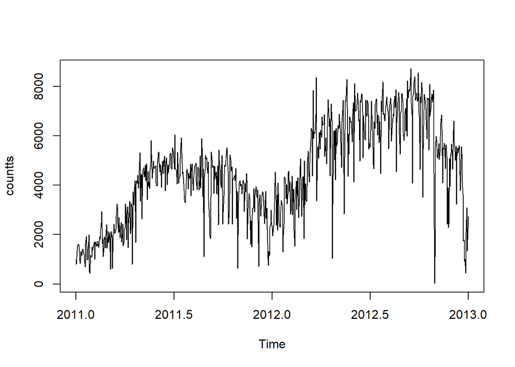

```r
countts <- ts(day$cnt, frequency=365, start=c(2011,1))
plot.ts(countts)
```

On decompose la time series pour bien voir la tendence et la saisonalite:

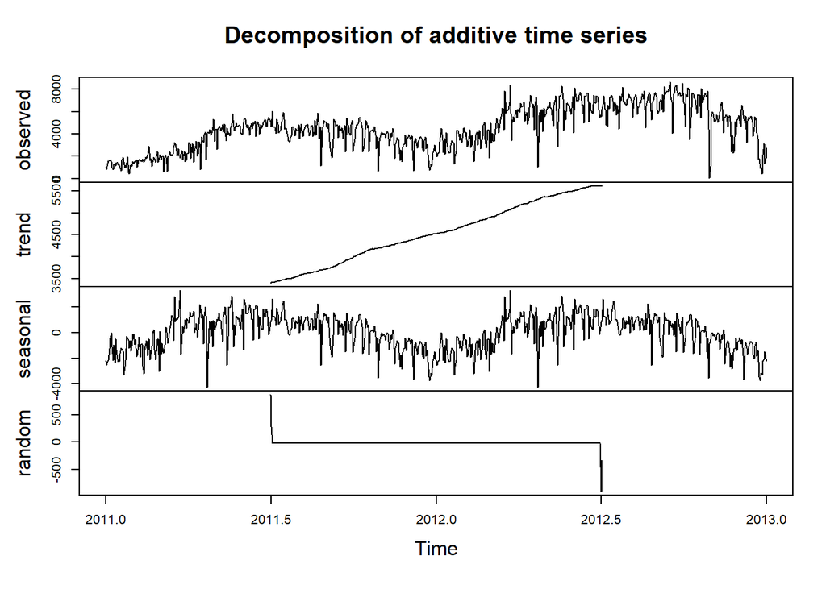

```r
counttscomponents <- decompose(countts)
plot(counttscomponents)
```

On remarque une tendance croissante, et on peut apercevoir deux saisons. La composante random, elle, n’est pas du tout stationnaire autours de 0 et ne forme pas un bruit blanc.

## 1)f) Enlever les outliers:

Pour enlever les outliers et les valuers manquantes de la time serie, on fait appel a la fonction `tsclean`:

```r
countts.clean <- tsclean(countts)
outliers.missing.val <- countts[countts.clean != countts]
outliers.missing.val
```

```
##  [1] 1543 1851 4036 4191 4595 4553 4660 4968 5515 1842 2395 2416 2424 2659  705
## [16] 8362 6857 7132 6624 4672 4549 4073 3510 5478   22 1096 4094 2277 2424 1341
```

```r
length(outliers.missing.val)
```

```
## [1] 30
```

```r
#first.cnt.ts.clean <-  tsclean(first_cnt_ts)
#outliers <- first_cnt_ts[first.cnt.ts.clean != first_cnt_ts ]
#outliers
```

On peut remarquer que la time serie de base countts contenait 30 outliers et/ou valeurs manquantes.

```r
plot.ts(countts.clean)
```

[output not shown]

### Lisser la time series:

Afin de lisser la ts, nous devons choisir la bonne méthode, pour cela, nous allons vérifier la tendance et la saisonnalité de la série, grace a la décomposition de la serie sans outliers:

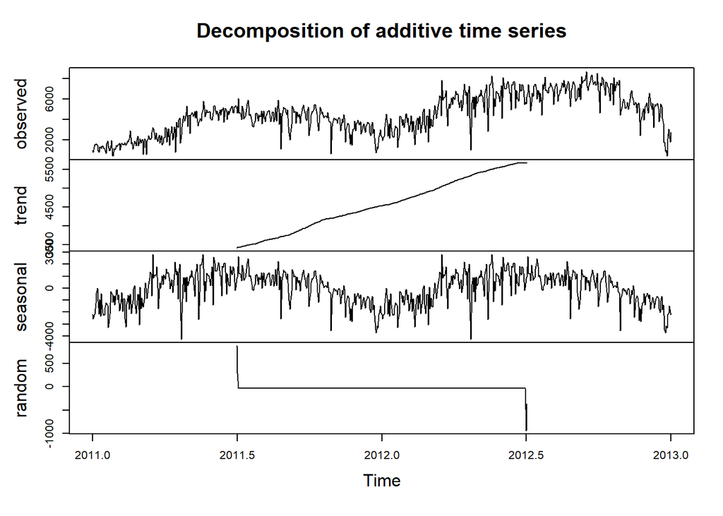

```r
cout.clean.components <- decompose(countts.clean)
plot(cout.clean.components)
```

On voit bien que la série a une tendance ascendante, mais on voit aussi que la composante random n’est pas stationnaire du tout et ne ressemble pas à un bruit blanc, ce qui nous fait nous interroger sur la composante saisonnalité de la série chronologique.

Cependant, nous allons en premier temps essayer de la lisser naïvement avec SMA:

#### Lissage SMA:

```r
cnt.ts.sma10 <- SMA(countts.clean, n=10)
plot.ts(countts.clean)
```

[output not shown]

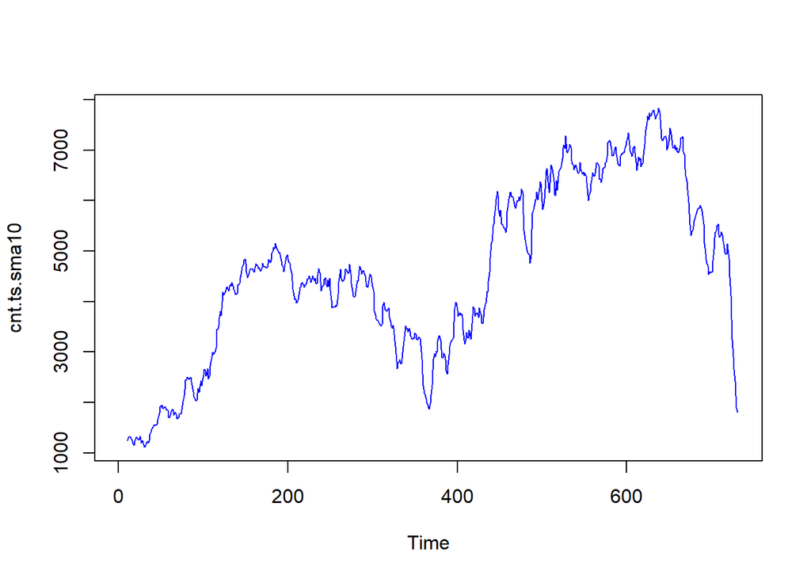

```r
plot.ts(cnt.ts.sma10, col = "blue")
```

La serie chronologique parait bien lissée avec SMA, car elle garde sa forme d’origine en enlevant les piques (les valeurs les plus extremes).

Nous pouvons aussi considerer que la serie chronologique a une saisonnalité, dans ce cas, on peut utiliser la méthode HoltsWinters pour la lisser :

#### Lissage HoltWinters:

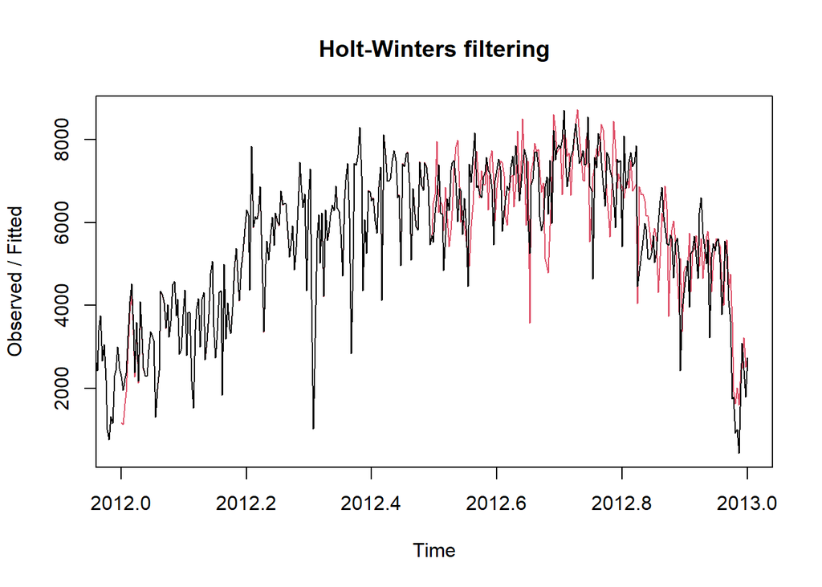

```r
cnt.ts.hw <- HoltWinters(countts.clean)
plot(cnt.ts.hw)
```

```r
plot.ts(countts.clean)
```

[output not shown]

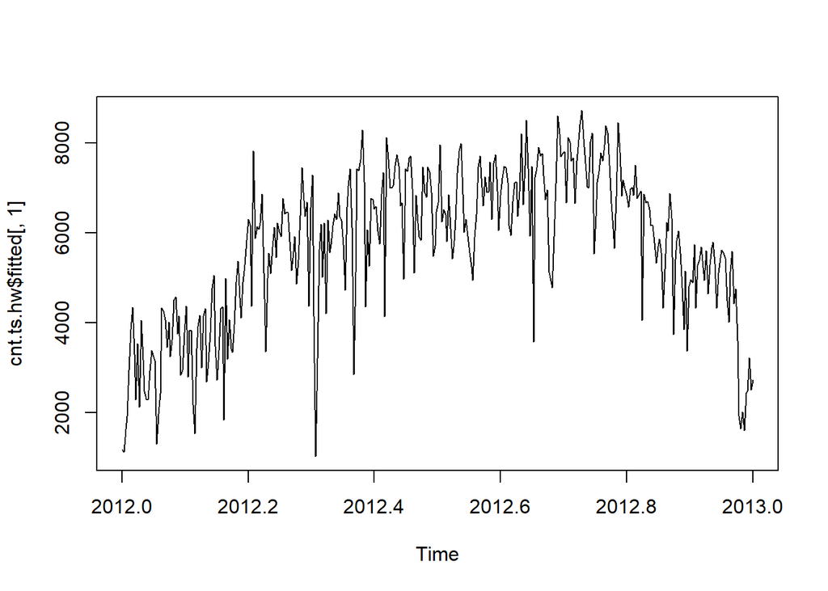

```r
plot.ts(cnt.ts.hw$fitted[,1])
```

```r
#cnt.ts.hw
#?HoltWinters
```

On remarque que la courbe qui resulte du lissage HoltWinters ne lisse pas assez bien l’entiereté de la série chronologique.

## 2 Choisir la meilleure methode de lissage:

Nous allons ajouter une fréquence aux deux séries lissées SMA et HoltWinters, puis nous analyserons les différences:

### Ajouter une fréquence a la série chronologique SMA:

On rajoute une frequence de 30 pour avoir une saisonalité par mois.

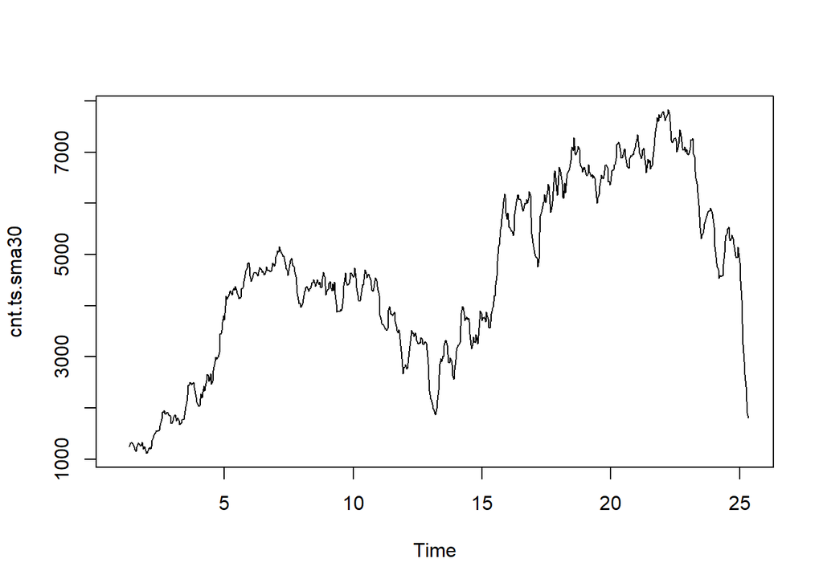

```r
cnt.ts.sma30 <- ts(cnt.ts.sma10, frequency = 30)
plot.ts(cnt.ts.sma30)
```

Pour avoir plus d’informations sur cette nouvelle série chronologique, nous allons la décomposer:

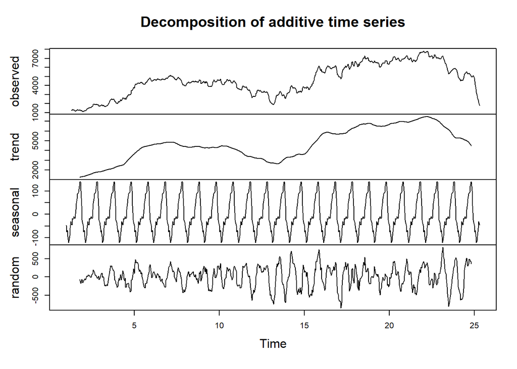

```r
dec.sma30 <- decompose(cnt.ts.sma30)
plot(dec.sma30)
```

On remarque assez facilement qu’il y a un pattern dans la saisonalité, et on peut apercevoir une tendance ascendante, (même si elle est moins claire que dans la décomposition précédante de 365)

Voyons si la composante random représente un bruit blanc, pour cela, nous allons utiliser le test Ljung

```r
Box.test(dec.sma30$random, type = "Ljung-Box")
```

```
##
##  Box-Ljung test
##
## data:  dec.sma30$random
## X-squared = 576.26, df = 1, p-value < 2.2e-16
```

La p-value est bien inferieure de 5%, ce qui nous mène à rejeter l’hypothèse nulle, i.e il reste une autocorrelation dans la série et elle ne représente pas un bruit blanc.

### Ajouter une fréquence a la série chronologique HoltWinters:

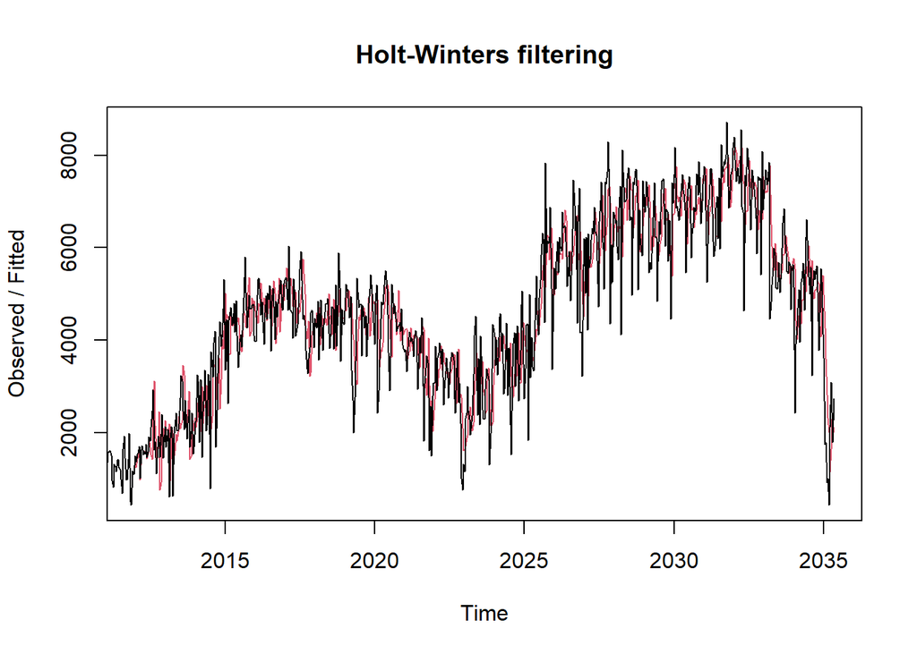

```r
#create a new time series with the right frequence
new.ts.30 <- ts(countts.clean, frequency = 30, start  = c(2011, 1))
#clean the ts
new.ts.clean30 <- tsclean(new.ts.30)

#smooth it using HoltWinters method
cnt.ts.hw30 <- HoltWinters(new.ts.clean30)
plot(cnt.ts.hw30)
```

```r
cnt.ts.hw30
```

```
## Holt-Winters exponential smoothing with trend and additive seasonal component.
##
## Call:
## HoltWinters(x = new.ts.clean30)
##
## Smoothing parameters:
##  alpha: 0.3445698
##  beta : 0.001784322
##  gamma: 0.149012
##
## Coefficients:
##           [,1]
## a   2400.53042
## b      1.93023
## s1   107.90503
## s2   138.28150
## s3    52.32732
## s4   -65.10501
## s5   126.40466
## s6  -203.31726
## s7    38.84877
## s8   -28.06696
## s9   410.89781
## s10  255.36043
## s11  188.27574
## s12  138.90948
## s13   30.57800
## s14  -67.22405
## s15 -166.51876
## s16 -427.11165
## s17 -648.24882
## s18 -222.47586
## s19 -157.91921
## s20 -138.84877
## s21 -515.39701
## s22 -245.25510
## s23 -409.05631
## s24 -197.30943
## s25  -88.52710
## s26 -171.40467
## s27   40.93787
## s28   55.93617
## s29 -111.23303
## s30  -73.26473
```

On remarque que le lissage HoltWinters apparait beaucoup mieux avec une frequence 30 plutot que la frequence 365 testée précédemment

Voyons maintenant sa décomposition:

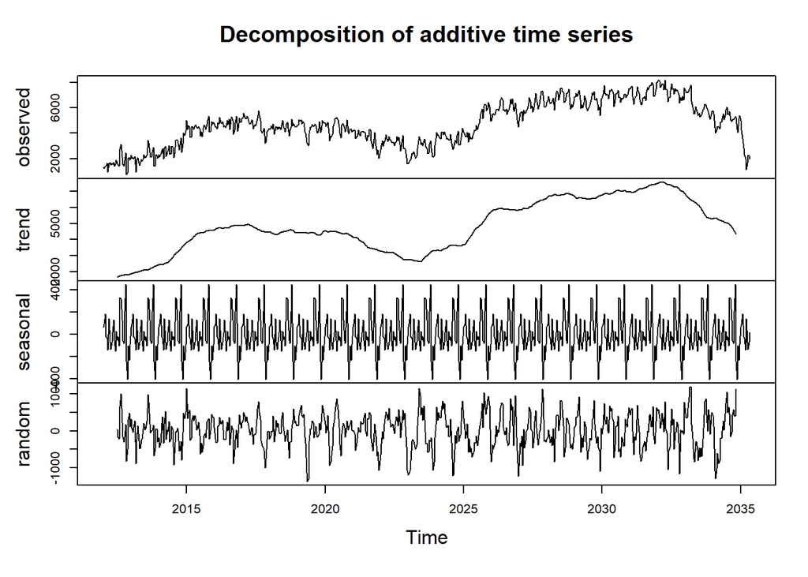

```r
decompose.hw30 <- decompose(cnt.ts.hw30$fitted[,1])
plot(decompose.hw30)
```

Il y a bien une saisonnalité assez claire, la tendance apparait proche que celle qu’on a observé dans la décomposition de SMA. Intéressons nous maintenant a la composante random et voyons si c’est un bruit blanc:

```r
Box.test(decompose.hw30$random, type = "Ljung")
```

```
##
##  Box-Ljung test
##
## data:  decompose.hw30$random
## X-squared = 287.34, df = 1, p-value < 2.2e-16
```

Ici aussi, on a une p-value inférieure a 5%, ce qui montre que la composante random n’est pas un bruit blanc. Ce qui veut dire qu’il reste encore de l’information dans la composante random qui n’a pas été pris en compte, dans la saisonalité ou dans la tendance de la série.

Cependant, comme on a bien remarqué une saisonalité dans la série chronologique en mettant la fréquence a 30, il serait mieux de choisir le lissage HoltWinters, qui est approprié pour une timeséries avec saisonalité.

## Modeliser la série lissée avec ARIMA:

Avant toute chose, nous devons nous assurer que la série chronologique est bien stationnaire, pour cela, on effectue un test `adf`:

```r
#récuperer la ts:
cnt.ts.hw <- cnt.ts.hw30$fitted[,1]

#tester la stationnarité:
adf.test(cnt.ts.hw)
```

```
##
##  Augmented Dickey-Fuller Test
##
## data:  cnt.ts.hw
## Dickey-Fuller = -0.80104, Lag order = 8, p-value = 0.9615
## alternative hypothesis: stationary
```

La p-value est supérieure a 5%, ce qui veut dire que la serie n’est pas stationnaire, il va falloir la différencier.

Pour estimer le nombre de différentiations qu’on doit faire a la série, on peut utiliser la fonction `ndiffs`

```r
ndiffs(cnt.ts.hw)
```

```
## [1] 1
```

On doit différencier une seule fois.

Intéressons nous maintenant aux ACF et PACF:

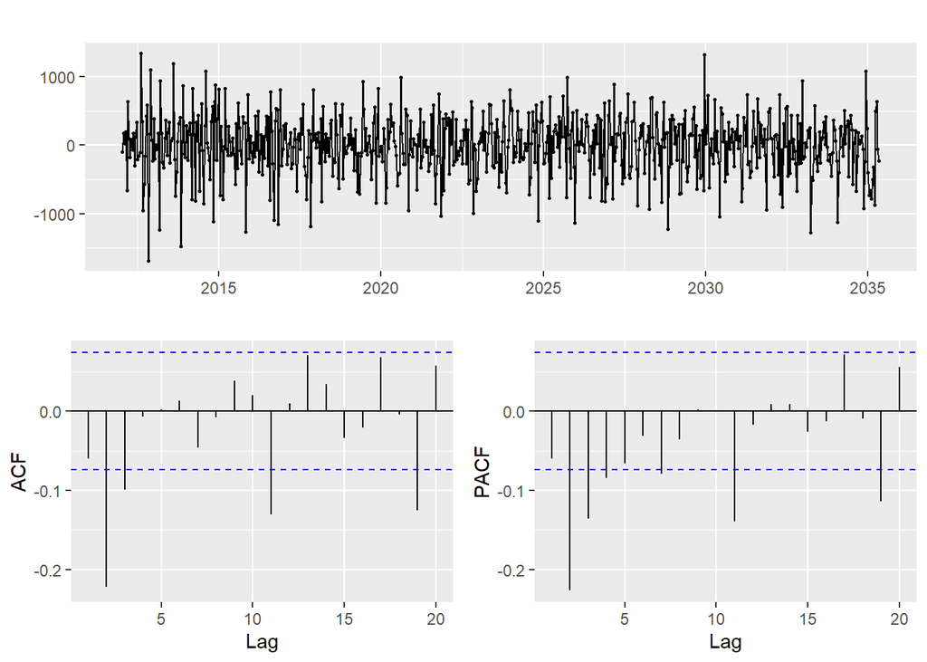

```r
cnt.ts.hw.diff <- diff(cnt.ts.hw, differences = 1 )
ggtsdisplay(cnt.ts.hw.diff, lag = 20)
```

Les modeles candidats sont MA(2), AR(4) (apres différenciation) ou ARIMA(4,1,2)

D’apres le principe de parsimonie, on devrait choisir le premier candidat MA(2), car il ne contient que deux parametres.

#### MA(2)

```r
cnt.ts.hw.ma2 <- arima(cnt.ts.hw, order = c(0,1,2))
cnt.ts.hw.ma2
```

```
##
## Call:
## arima(x = cnt.ts.hw, order = c(0, 1, 2))
##
## Coefficients:
##           ma1      ma2
##       -0.1624  -0.2831
## s.e.   0.0368   0.0374
##
## sigma^2 estimated as 178718:  log likelihood = -5226.11,  aic = 10458.23
```

Predictions du modele MA(2):

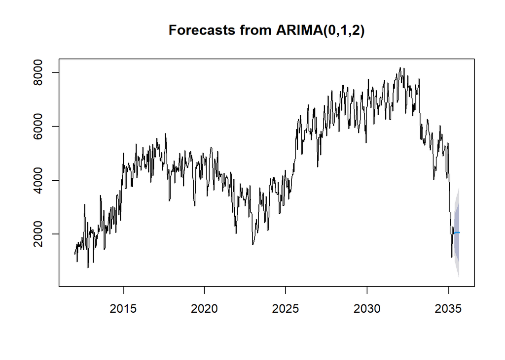

```r
cnt.ts.hw.ma2.forecast <- forecast(cnt.ts.hw.ma2, h = 10)
plot(cnt.ts.hw.ma2.forecast)
```

Le forecast n’a pas l’air tres satisfaisant, car la prediction est une ligne droite.

Voyons les résiduels de ce forecast:

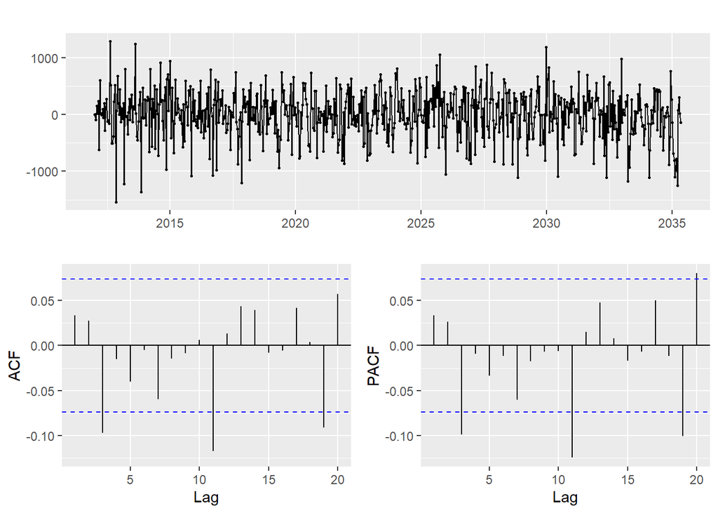

```r
ggtsdisplay(cnt.ts.hw.ma2.forecast$residuals, lag = 20)
```

On remarque qu’il reste quand meme des lags (3) non nuls dans les ACF des résiduels.

```r
Box.test(cnt.ts.hw.ma2.forecast$residuals, type = "Ljung-Box")
```

```
##
##  Box-Ljung test
##
## data:  cnt.ts.hw.ma2.forecast$residuals
## X-squared = 0.79688, df = 1, p-value = 0.372
```

La p-value est supérieure a 5%, ce qui veut dire que les résiduels peuvent etre interpretés comme un bruit blanc.

On s’interesse aux deux autres modeles pour comparer leurs resultats:

#### AR(4)

```r
cnt.ts.hw.ar4 <- arima(cnt.ts.hw, order = c(4,1,0))
cnt.ts.hw.ar4
```

```
##
## Call:
## arima(x = cnt.ts.hw, order = c(4, 1, 0))
##
## Coefficients:
##           ar1      ar2      ar3      ar4
##       -0.1152  -0.2558  -0.1446  -0.0840
## s.e.   0.0377   0.0375   0.0375   0.0377
##
## sigma^2 estimated as 178294:  log likelihood = -5225.27,  aic = 10460.54
```

Predictions du modele AR(4):

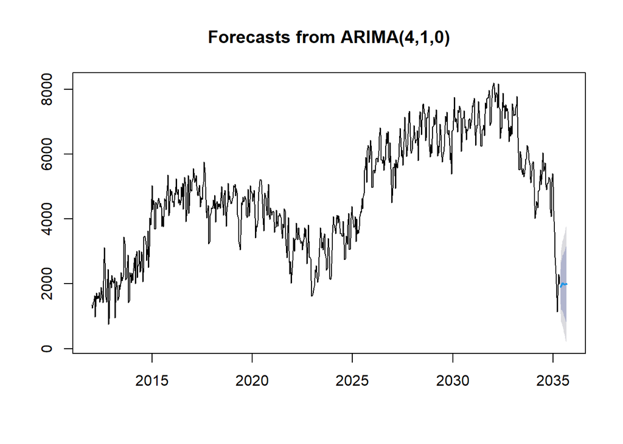

```r
cnt.ts.hw.ar4.forecast <- forecast(cnt.ts.hw.ar4, h = 10)
plot(cnt.ts.hw.ar4.forecast)
```